# 06 — pixel measurement over the corpus, including one real null

**Summary.** This notebook does not recompute any pixel metric. `corpus surface`, `corpus vocabulary` and `corpus audit` have careful definitions — what a sheet's ground is, what counts as an untouched margin, how a permutation baseline is drawn — and a PIL re-implementation would be a second thing to keep correct. So this prints the CLI's own output and adds only the pictures.

The findings the CLI reports, and they are mostly negative:

- **Only 9 of 1,500 sampled images are sheets with a measurable ground.** Museums shoot 2D works with the mount inside the frame, so plate-unit measurement mostly fails on this corpus.
- **Real sheets touch their edges** (edgeContact median 0.06–0.13) **while all 7 measurable plates read 0.0000 top, right and left.** The artist's plates and the corpus's sheets differ in a way the envelope's 0..1 binning cannot express.
- **The reading-vs-pixel audit is a REAL NULL**: off-centre median 0.0439 against centred 0.0440, chance 100%, over a 40x offset range. That is not an instrument failure — the instrument has the range and there is nothing there.

```python
import sys, pathlib
sys.path.insert(0, str(pathlib.Path.cwd()))
import numpy as np, pandas as pd
import matplotlib.pyplot as plt
import kusama as k
```

## `corpus surface` — what a sheet is, and how few there are

```python
print(k.run_cli("surface"))
```

```
20000 manifest row(s) in; 1500 image(s) read; 277 measurable.

rows that produced no image:
  18291  not in the stride sample
    111  the manifest row has no image
     98  another row holds the same bytes

images read and not measured:
   1223  the border is not one colour, so there is no ground to measure ink against — a mount, a frame or a lit gradient reads as ink over the whole backdrop

Every image, photographs of objects included. These describe the file: the aspect is the
photograph's shape and the palette includes the backdrop it was shot against. weight.* is
defined even where there is no ground, and is the only one of these a composition claim can
be checked against — read it as a percentile of this band, never as an absolute.
field                       n   min     p10     med     p90     max
  logAspect             n= 1500 min -2.6153 p10 -0.6360 med -0.0144 p90 0.6845 max 3.3380
  tone.mean             n= 1500 min 0.0907 p10 0.3535 med 0.6122 p90 0.8118 max 0.9531
  tone.sd               n= 1500 min 0.0314 p10 0.1047 med 0.1833 p90 0.2739 max 0.4176
  palette.distinct      n= 1500 min 12.0000 p10 109.0000 med 271.0000 p90 621.0000 max 2757.0000
  palette.concentration n= 1500 min 0.0015 p10 0.0392 med 0.1193 p90 0.2323 max 0.8750
  energy.gradient       n= 1500 min 0.0011 p10 0.0063 med 0.0164 p90 0.0443 max 0.1633
  weight.offset         n= 1500 min 0.0002 p10 0.0112 med 0.0451 p90 0.1325 max 0.2924
  weight.spread         n= 1500 min 0.1907 p10 0.4332 med 0.5070 p90 0.5763 max 0.6430
  ground.share          n= 1500 min 0.0179 p10 0.2300 med 0.4420 p90 0.9995 max 1.0000
  ground.extent         n= 1500 min 0.0044 p10 0.0672 med 0.2533 p90 0.6846 max 0.9857

Commensurable with a rendered plate: 277 image(s) on a confident ground, split by
what the numbers are about. These bands are never pooled.

  sheet (9) — a sheet: these metrics mean what the aesthetic layer means by them
  field                       n   min     p10     med     p90     max
    inkDensity            n=    9 min 0.2566 p10 0.2566 med 0.6600 p90 0.8788 max 0.8788
    coverage              n=    9 min 0.3398 p10 0.3398 med 0.8555 p90 1.0000 max 1.0000
    inkOffset             n=    9 min 0.0256 p10 0.0256 med 0.0650 p90 0.2285 max 0.2285
    symmetry.vertical     n=    9 min 0.5600 p10 0.5600 med 0.9090 p90 0.9830 max 0.9830
    symmetry.horizontal   n=    9 min 0.4975 p10 0.4975 med 0.7610 p90 0.9782 max 0.9782
    edgeContact.top       n=    9 min 0.0000 p10 0.0000 med 0.1026 p90 0.3396 max 0.3396
    edgeContact.right     n=    9 min 0.0000 p10 0.0000 med 0.0572 p90 0.1903 max 0.1903
    edgeContact.bottom    n=    9 min 0.0000 p10 0.0000 med 0.0624 p90 0.2011 max 0.2011
    edgeContact.left      n=    9 min 0.0000 p10 0.0000 med 0.1270 p90 0.5787 max 0.5787
```

[output cut: 9 more lines]

```
    edgeContact.right     n=  254 min 0.0000 p10 0.0000 med 0.0000 p90 0.0510 max 0.4001
    edgeContact.bottom    n=  254 min 0.0000 p10 0.0000 med 0.0000 p90 0.0805 max 0.6224
    edgeContact.left      n=  254 min 0.0000 p10 0.0000 med 0.0000 p90 0.0490 max 0.3471

  unknown (14) — nothing has said whether this is a sheet or an object, so what these metrics are about is unknown and no band may be built from them
  field                       n   min     p10     med     p90     max
    inkDensity            n=   14 min 0.2371 p10 0.2665 med 0.4903 p90 0.7724 max 0.8677
    coverage              n=   14 min 0.3359 p10 0.3555 med 0.7578 p90 0.8711 max 1.0000
    inkOffset             n=   14 min 0.0073 p10 0.0073 med 0.0184 p90 0.1368 max 0.2286
    symmetry.vertical     n=   14 min 0.2868 p10 0.4114 med 0.8414 p90 0.9721 max 0.9837
    symmetry.horizontal   n=   14 min 0.4528 p10 0.4806 med 0.7187 p90 0.9735 max 0.9859
    edgeContact.top       n=   14 min 0.0000 p10 0.0000 med 0.0009 p90 0.2350 max 0.4675
    edgeContact.right     n=   14 min 0.0000 p10 0.0000 med 0.0003 p90 0.0879 max 0.1795
    edgeContact.bottom    n=   14 min 0.0000 p10 0.0000 med 0.0000 p90 0.0589 max 0.2516
    edgeContact.left      n=   14 min 0.0000 p10 0.0000 med 0.0011 p90 0.1651 max 0.2268
```

## `corpus vocabulary` — the paper terms that explain the metadata neighbours

```python
print(k.run_cli("vocabulary"))
```

```
20000 works, by what the catalogue says they physically are:
  2d         2930  14.7%
  object    16126  80.6%
  unknown     944  4.7%

and per museum, because the mix is a fact about collecting, not about art:
  aic        6817  2d 27.6%  object 68.2%  unknown 4.3%
  cma        3183  2d 16.7%  object 74.8%  unknown 8.4%
  met       10000  2d 5.2%  object 91.0%  unknown 3.9%

the most distinctive terms in `all` (1525 cleared the floor):
  elements                 tfidf 19.221  in 33 works, 99 times
  jalisco                  tfidf 14.371  in 21 works, 44 times
  sevres                   tfidf 13.546  in 26 works, 53 times
  rekhmire                 tfidf 13.369  in 25 works, 50 times
  ensemble                 tfidf 13.315  in 22 works, 43 times
  harpokrates              tfidf 13.315  in 22 works, 43 times
  label                    tfidf 13.065  in 21 works, 40 times
  twisted                  tfidf 12.908  in 28 works, 55 times
  teapot                   tfidf 12.610  in 24 works, 45 times
  float                    tfidf 12.522  in 31 works, 60 times
  chisel                   tfidf 12.434  in 20 works, 36 times
  nigeria                  tfidf 12.434  in 20 works, 36 times
  nefertari                tfidf 12.171  in 29 works, 54 times
  corona                   tfidf 12.089  in 20 works, 35 times
  siptah                   tfidf 12.085  in 21 works, 37 times
  evening                  tfidf 11.971  in 35 works, 66 times
  nefertiti                tfidf 11.816  in 34 works, 63 times
  lace                     tfidf 11.805  in 76 works, 161 times
  sketchbook               tfidf 11.770  in 23 works, 40 times
  sickle                   tfidf 11.770  in 24 works, 42 times
  desk                     tfidf 11.767  in 22 works, 38 times
  wah                      tfidf 11.767  in 22 works, 38 times
  colima                   tfidf 11.713  in 43 works, 82 times
  sampler                  tfidf 11.687  in 31 works, 56 times
  seti                     tfidf 11.432  in 21 works, 35 times
  snake                    tfidf 11.432  in 21 works, 35 times
  ahmose                   tfidf 11.404  in 44 works, 82 times
  wedding                  tfidf 11.342  in 40 works, 73 times
  mezzotint                tfidf 11.271  in 30 works, 52 times
```

[output cut: 41 more lines]

```
  calligraphy      ~ colors           7.21x chance  support 74
  ankh             ~ scarabs          7.11x chance  support 41
  hieroglyphs      ~ scarabs          6.94x chance  support 41
  inscribed        ~ scarabs          6.88x chance  support 41
  desk             ~ tulip            6.88x chance  support 20
  name             ~ scarabs          6.72x chance  support 41
  slit             ~ tunic            6.70x chance  support 26
  hours            ~ initial          6.66x chance  support 24
  calligraphy      ~ handscroll       6.66x chance  support 48
  back             ~ scarabs          6.64x chance  support 41
  nefer            ~ scarabs          6.63x chance  support 41
  desk             ~ poplar           6.57x chance  support 22
  scarab           ~ scaraboids       6.56x chance  support 20
  blown            ~ pressed          6.50x chance  support 60
  arms             ~ parts            6.48x chance  support 69
```

## `corpus audit` — the null, with its permutation baseline

The question: does what a model *says* about a work correlate with where the work sits in the frame? The answer is no, and the notebook prints the range over which it is no.

```python
print(k.run_cli("audit"))
```

```
24/50 readings make a claim about where the weight sits
0 say both things and are excluded
0 have a claim and no measurement

weight.offset by what the reading said, over 10000 label shuffles:
  all            n 17 vs 7    off-centre median 0.0439  centred median 0.0440
                              separation -0.0002  chance 100.0%  — NOTHING MEASURED — chance produces this gap as often as not
  recognised     n 11 vs 4    NOT STATED — under 5 in a group, so the medians are anecdotes
  unrecognised   n 6 vs 3     NOT STATED — under 5 in a group, so the medians are anecdotes

The recognised/unrecognised split is NOT STATED at this sample size.
```

## The 2D minority, as pictures

The point of showing these is that "only 14.7% is 2D" is a number and *this* is why: most corpus images are an object on a backdrop, and the backdrop is the museum's.

```
dimensionality == 2d  (2,914 works, 14.7% of the corpus)
```

[figure not shown]

```
dimensionality == object  (15,943 works, 80.6% of the corpus)
```

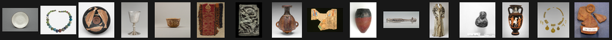

```python
m = k.load_manifest()
kept = m[m.embedding_row.notna()]
rng = np.random.default_rng(7)
for label, sel in [("dimensionality == 2d", kept[kept.dimensionality == "2d"]),
                   ("dimensionality == object", kept[kept.dimensionality == "object"])]:
    print(f"\n{label}  ({len(sel):,} works, {len(sel)/len(kept):.1%} of the corpus)")
    display(k.thumb_grid(list(sel.sha256.iloc[rng.integers(0, len(sel), 16)]), cols=16, size=62))
```

## Aspect, the one metric that is safe to read from the manifest

Width and height are recorded by the ingest, not inferred, so this is the one geometric fact that does not depend on a segmentation working.

```python
a = kept.aspect.dropna()
print(f"corpus aspect: median {a.median():.3f}, IQR {a.quantile(.25):.3f}..{a.quantile(.75):.3f}")
for d in k.trajectory_dirs():
    t = k.load_trajectory(d)
    pa = pd.Series([p["aspect"] for p in t["plates"]])
    pct = (a < pa.median()).mean()
    print(f"{d:<26} {len(pa):>3} plates, median aspect {pa.median():.3f} — "
          f"{pct:.1%} of corpus images are narrower")
print("\nThe plates are portrait and the corpus is 51.2% portrait, so aspect is NOTHING MEASURED as a")
print("distinguishing feature. It is here so nobody has to wonder.")
```

```
corpus aspect: median 0.980, IQR 0.749..1.333
out/condition-withheld      17 plates, median aspect 0.743 — 23.2% of corpus images are narrower
out/first-withheld          18 plates, median aspect 0.743 — 23.2% of corpus images are narrower
out/openai-withheld         17 plates, median aspect 0.743 — 23.2% of corpus images are narrower

The plates are portrait and the corpus is 51.2% portrait, so aspect is NOTHING MEASURED as a
distinguishing feature. It is here so nobody has to wonder.
```

## Scratch

```python
# yours
```